# Medidas de tendencia central

[Moises Cruz Serrano](https://moisescs1.github.io/)

Taller IV 2022-2, [Facultad de economía](http://www.economia.unam.mx/)

4/3/2022

### 1. ¿Qué son las medidas de tendencia central? 🤔

> Definición:  
> “Las medidas de tendencia central son parámetros estadísticos que informan sobre el centro de la distribución de la muestrao población estadística.” [Economipedia (2019)](https://economipedia.com/definiciones/medidas-de-tendencia-central.html)

Para este ejemplo, primero generaremos una serie de **100** números aleatorios entre **1** y **20** mediante la función `sample`. El argumento `TRUE` nos permitirá generar una muestra con remplazo:

```r
numeros <- sample(1:20, 100, TRUE)
numeros
```

```
##   [1] 20  7 20 15 10  6  3 10  3  7 16 20 20  1 19  5 15  1  1  6 14 10  6 20 10
##  [26] 13  2 20 18  4 10 16 20 11 20 13  8  5 19 14  2  4  3  5 14 16  3  4 14  1
##  [51]  1 13  4  4  1  4 19  6  7  3 16  8  6  7  2 20 12  9 18  8 19  1  2  9  4
##  [76]  8  5  8 18  9  3 15 17 18  5 12 14  3 12  4 20 13  8 12  2 20  5 13  6  9
```

### 2. Mediana 📍

> Definición:  
> “La mediana es un estadístico de posición central que parte la distribución en dos, es decir, deja la misma cantidad de valores a un lado que a otro.” [Economipedia (2019)](https://economipedia.com/definiciones/mediana.html)

Para obtener la **mediana**, podemos ordenar los `numeros` de menor a mayor, **el número que esté en medio de la muestra será la mediana**. Si utilizamos R, se puede hacer el cálculo de la **mediana** con la función `median`:

```r
mediana <- median(numeros)
mediana
```

```
## [1] 9
```

### 3. Media 🧮

> Definición:  
> “La media es el valor promedio de un conjunto de datos numéricos, calculada como la suma del conjunto de valores dividida entre el número total de valores.”  
> [Economipedia (2019)](https://economipedia.com/definiciones/media.html)

$$Media ={\frac {1}{n}}\sum _{i=1}^{n}a_{i}={\frac {a_{1}+a_{2}+\cdots +a_{n}}{n}}$$

Si usamos R, podemos obtener la media de una muestra si utlilizamos la función **mean**:

```r
media <- mean(numeros)
media
```

```
## [1] 9.86
```

### 4. Moda 📊

> Definición:  
> “La moda es el valor que más se repite en una muestra estadística o población. No tiene fórmula en sí mismo. Lo que habría que realizar es la suma de las repeticiones de cada valor.”  
> [Economipedia (2019)](https://economipedia.com/definiciones/medidas-de-tendencia-central.html)

Podemos saber cuál es la **frecuencia** (número de veces que aparece un elemento en una muestra) de cada número si dibujamos un **histograma** con la función `hist`, **aquel elemento con mayor frecuencia será la moda**:

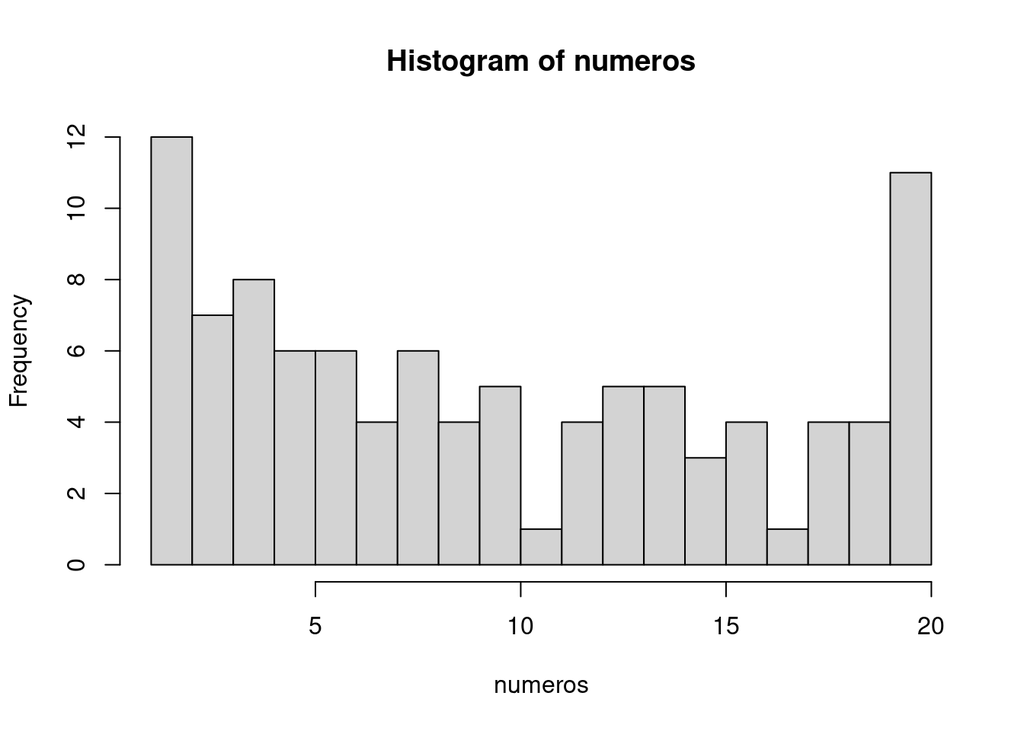

```r
# El argumento breaks nos permite dividir en histograma en las partes que queramos
hist(numeros, breaks = 20)
```

Para obtener un resultado con más precisión, podemos obtener la **moda** si generamos una **tabla de frecuencias** con la función `table` y la función `data.frame`, **aquel elemento con mayor frecuencia será la moda**:

```r
tabla.frecuencias <- data.frame(table(numeros))
tabla.frecuencias
```

```
##    numeros Freq
## 1        1    7
## 2        2    5
## 3        3    7
## 4        4    8
## 5        5    6
## 6        6    6
## 7        7    4
## 8        8    6
## 9        9    4
## 10      10    5
## 11      11    1
## 12      12    4
## 13      13    5
## 14      14    5
## 15      15    3
## 16      16    4
## 17      17    1
## 18      18    4
## 19      19    4
## 20      20   11
```

### 5. Ejercicio 👩‍💻👨‍💻✍

Aplica lo que aprendiste, obten la **mediana**, **media** y **moda** de la siguiente muestra de números:

```r
# Con la función seq, creamos una secuencia de 1 a 10 en intervalos de 0.1 en 0.1
secuencia <- seq(1, 10, 0.1)
muestra <- sample(secuencia, 100, TRUE)
muestra
```

```
##   [1]  7.6  6.6  1.2  5.1  2.5  7.6  6.5  3.6  4.4  5.2  3.2  5.9  8.5  5.7  9.2
##  [16]  1.9  2.8  8.4  7.8  6.7  2.1  9.9  5.5  1.2  8.5  2.4 10.0  9.2  6.2  2.6
##  [31]  3.2  1.0  7.1  6.4  8.4  1.4  8.7  8.0  5.9  9.3  5.6  5.8  9.4  9.5  9.5
##  [46]  9.1  2.2  8.3  4.2  5.3  5.1  8.2  7.2  9.9  9.3  7.4  6.1  3.7  2.6  5.1
##  [61]  1.6  4.9  5.7  5.0  1.7  7.1  7.8  9.5  2.0  5.7  3.4  5.5  6.5  8.1  5.5
##  [76]  8.4  1.6  5.5  7.4  5.3  4.4  5.1  6.3  9.4  1.1  1.4  8.7  3.6  2.7  4.8
##  [91]  6.7  1.5  2.3  8.4  7.3  1.6  6.7  5.6  5.7  7.5
```

##### Mediana

```r
# Aquí el cálculo de la mediana
mediana <- median(muestra)
mediana
```

```
## [1] 5.7
```

##### Media

```r
# Aquí el cálculo de la media
media <- mean(muestra)
media
```

```
## [1] 5.699
```

##### Moda

```r
# Aquí el cálculo de la moda
tabla.moda <- data.frame(table(muestra))
tabla.moda
```

```
##    muestra Freq
## 1        1    1
## 2      1.1    1
## 3      1.2    2
## 4      1.4    2
## 5      1.5    1
## 6      1.6    3
## 7      1.7    1
## 8      1.9    1
## 9        2    1
## 10     2.1    1
## 11     2.2    1
## 12     2.3    1
## 13     2.4    1
## 14     2.5    1
```

[output cut: 48 more lines]

💻[Código disponible en RStudio Cloud](https://rstudio.cloud/project/3671022)💻